# Notebook 10 – Solutions

## Getting Started

Before running this notebook, select “Session > Restart R and Clear Output” in the menu above to start a new R session. This will clear any old data sets and give us a blank slate to start with.

After starting a new session, run the following code chunk to load the libraries and data that we will be working with today.

I have set the options `include=FALSE` and `message=FALSE` to avoid cluttering the solutions with all the output from this code.

# Practice

## Load data sets

In this notebook we will work with the U.S. city population data set.

```r
us <- read_csv(file.path("data", "us_city_population.csv"))
```

Please refer to notebook02a for more information about the data set.

## Widening Data: Cities as Observations

The `us` cities data set is a perfect candidate for widening. In its default form, there is one row for each unique combination of year and city. However, some plots and analyses are easier if we create a data set with either time or the cities.

Let’s start by creating a widened data set where each row is a city. The years will then be turned into columns. In the code below, create this data set using the `pivot_wider` function, with names coming from the years and values from the population. As we saw previously, use the names prefix “year_” to avoid column names staring with a number.

```r
us %>%
  pivot_wider(
    names_from = year, values_from = population, names_prefix = "year_"
   )
```

```
## # A tibble: 300 × 27
##    city     state    lon   lat year_1790 year_1800 year_1810 year_1820 year_1830
##    <chr>    <chr>  <dbl> <dbl>     <dbl>     <dbl>     <dbl>     <dbl>     <dbl>
##  1 Anchora… AK    -149.   61.2         0         0         0         0      0
##  2 Birming… AL     -86.8  33.5         0         0         0         0      0
##  3 Huntsvi… AL     -86.5  34.8         0         0         0         0      0
##  4 Mobile,… AL     -88.1  30.7         0         0         0         0      3.19
##  5 Montgom… AL     -86.3  32.3         0         0         0         0      0
##  6 Little … AR     -92.4  34.7         0         0         0         0      0
##  7 Chandle… AZ    -112.   33.3         0         0         0         0      0
##  8 Gilbert… AZ    -112.   33.3         0         0         0         0      0
##  9 Glendal… AZ    -112.   33.5         0         0         0         0      0
## 10 Mesa, AZ AZ    -112.   33.4         0         0         0         0      0
## # … with 290 more rows, and 18 more variables: year_1840 <dbl>,
## #   year_1850 <dbl>, year_1860 <dbl>, year_1870 <dbl>, year_1880 <dbl>,
## #   year_1890 <dbl>, year_1900 <dbl>, year_1910 <dbl>, year_1920 <dbl>,
## #   year_1930 <dbl>, year_1940 <dbl>, year_1950 <dbl>, year_1960 <dbl>,
## #   year_1970 <dbl>, year_1980 <dbl>, year_1990 <dbl>, year_2000 <dbl>,
## #   year_2010 <dbl>
```

Below, take the data set created in the previous block and filter to include only cities with a population above 600 thousand in 2010. (Note: Do this after the pivot. It is much easier that way.) Then, plot the population of each city in 1950 on the x-axis and the population in 2010 on the y-axis with points and a text repel layer using the city names. Use logarithmic scales for the x- and y-axes.

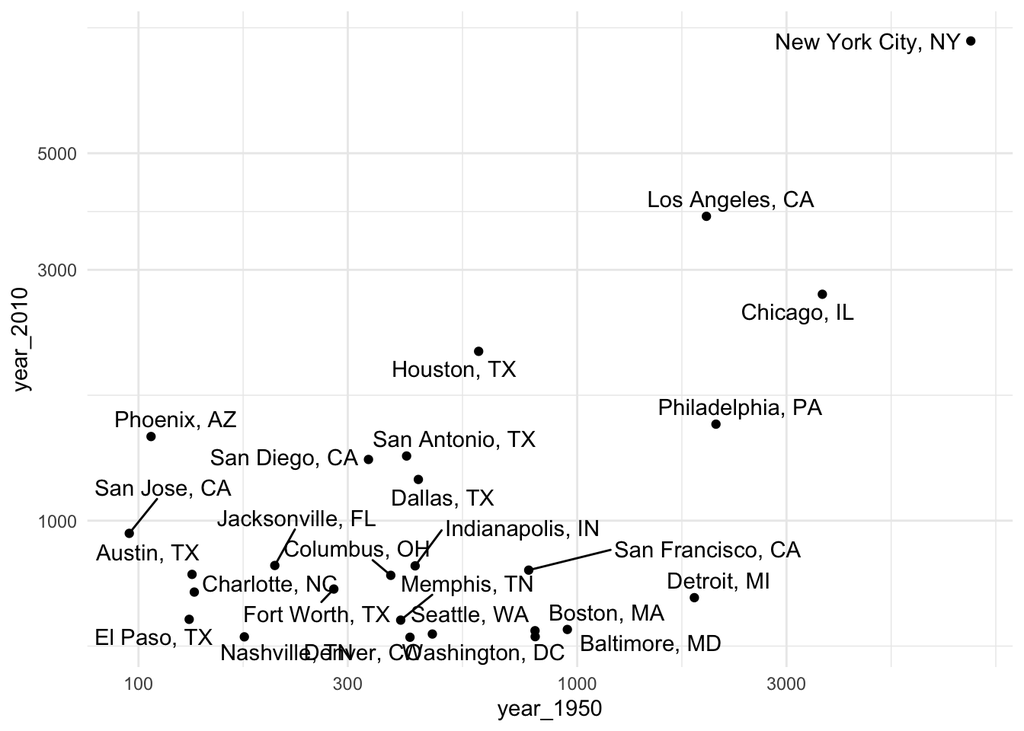

```r
us %>%
  pivot_wider(
    names_from = year, values_from = population, names_prefix = "year_"
   ) %>%
  filter(year_2010 > 600) %>%
  ggplot(aes(year_1950, year_2010)) +
    geom_text_repel(aes(label = city)) +
    geom_point() +
    scale_x_log10() +
    scale_y_log10()
```

Another graph that we can create using the wide version of the data set is an arrow plot showing the trend of each city over time. Below, piping the same data in as above, create a plot using the `geom_segment` layer with city of the y-axis and population on the x-axis. However, for this layer, you need to describe two additional aesthetics: `xend` and `yend`. Set `x` to the population in 1950 and `xend` to the population in 2010. The value for `yend` should be equal to the city name, the same as `y`.

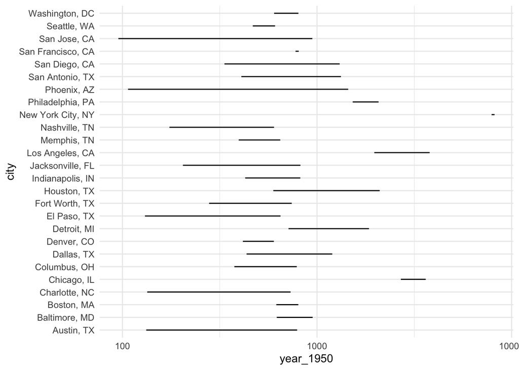

```r
us %>%
  pivot_wider(
    names_from = year, values_from = population, names_prefix = "year_"
   ) %>%
  filter(year_2010 > 600) %>%
  ggplot(aes(year_1950, city)) +
    geom_segment(aes(xend = year_2010, yend = city)) +
    scale_x_log10()
```

One issue with this plot is that it does not show which direction the population is changing (is it increasing or decreasing between 1950 and 2010?). We can fix this by adding an option to the `geom_segment` layer that turns the segment into an arrow. Namely:

`arrow = arrow(length = unit(0.02, "npc"))`

Below, modify the previous plot to include an arrow. Note that this line goes inside the `geom_segement` function, after the `aes` command. You may need to indent into a new line as is sometimes done in the notes to make the code easily readable. The `0.02` effects the size of the arrow and can be modified as you see fit.

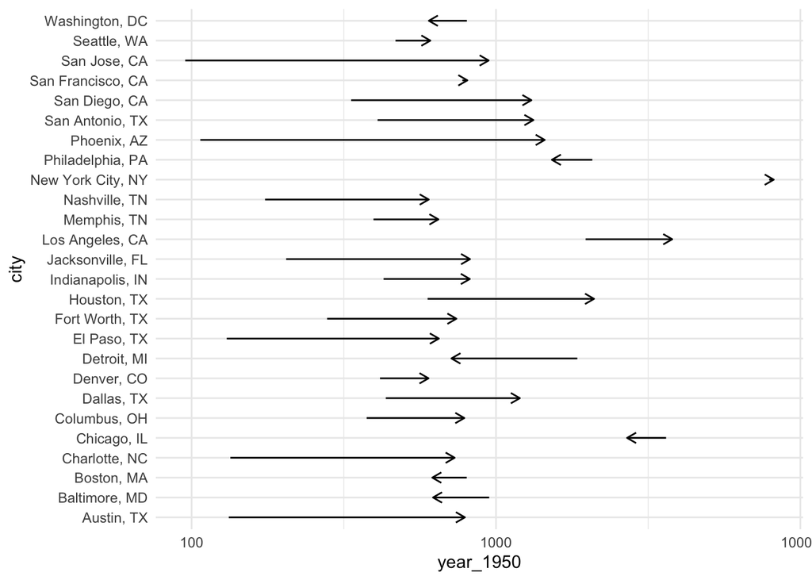

```r
us %>%
  pivot_wider(
    names_from = year, values_from = population, names_prefix = "year_"
   ) %>%
  filter(year_2010 > 600) %>%
  ggplot(aes(year_1950, city)) +
    geom_segment(
      aes(xend = year_2010, yend = city),
      arrow = arrow(length = unit(0.02, "npc"))
    ) +
    scale_x_log10()
```

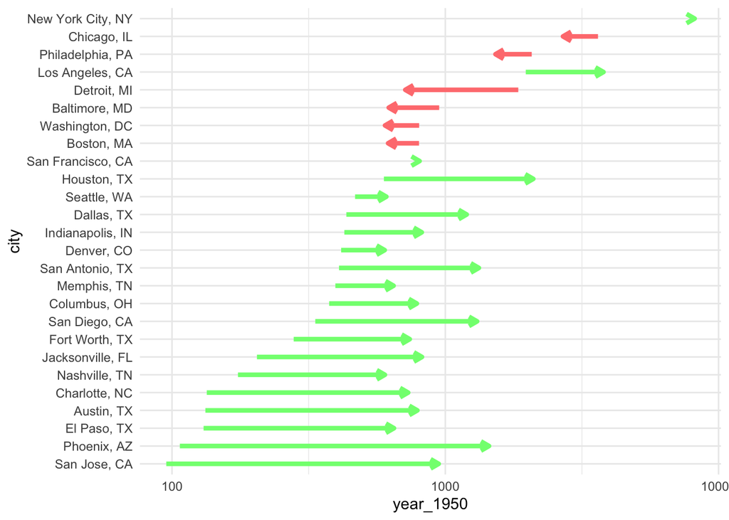

```r
us %>%
  pivot_wider(
    names_from = year, values_from = population, names_prefix = "year_"
   ) %>%
  filter(year_2010 > 600) %>%
  mutate(color = if_else(year_1950 > year_2010, "#FF7F7F", "#7FFF7F")) %>%
  arrange(year_1950) %>%
  mutate(city = fct_inorder(city)) %>%
  ggplot(aes(year_1950, city)) +
    geom_segment(
      aes(xend = year_2010, yend = city, color = color),
      size = 1.5,
      arrow = arrow(length = unit(0.02, "npc"))
    ) +
    scale_x_log10() +
    scale_color_identity()
```

## Widening Data: Years as Observations

Another possibility for pivoting the `us` data set is to have the observations be years and the variables be the cities In the code block below, try to `pivot_wider` using names from the city variable and values from the population. We do not need a variable prefix here.

```r
us %>%
  pivot_wider(names_from = city, values_from = population)
```

```
## # A tibble: 6,808 × 304
##    state  year    lon   lat `Anchorage, AK` `Birmingham, AL` `Huntsville, AL`
##    <chr> <dbl>  <dbl> <dbl>           <dbl>            <dbl>            <dbl>
##  1 AK     1790 -149.   61.2               0               NA               NA
##  2 AL     1790  -86.8  33.5              NA                0               NA
##  3 AL     1790  -86.5  34.8              NA               NA                0
##  4 AL     1790  -88.1  30.7              NA               NA               NA
##  5 AL     1790  -86.3  32.3              NA               NA               NA
##  6 AR     1790  -92.4  34.7              NA               NA               NA
##  7 AZ     1790 -112.   33.3              NA               NA               NA
##  8 AZ     1790 -112.   33.3              NA               NA               NA
##  9 AZ     1790 -112.   33.5              NA               NA               NA
## 10 AZ     1790 -112.   33.4              NA               NA               NA
## # … with 6,798 more rows, and 297 more variables: Mobile, AL <dbl>,
## #   Montgomery, AL <dbl>, Little Rock, AR <dbl>, Chandler, AZ <dbl>,
## #   Gilbert, AZ <dbl>, Glendale, AZ <dbl>, Mesa, AZ <dbl>, Peoria, AZ <dbl>,
## #   Phoenix, AZ <dbl>, Scottsdale, AZ <dbl>, Tempe, AZ <dbl>, Tucson, AZ <dbl>,
## #   Anaheim, CA <dbl>, Antioch, CA <dbl>, Bakersfield, CA <dbl>,
## #   Berkeley, CA <dbl>, Burbank, CA <dbl>, Carson, CA <dbl>,
## #   Chula Vista, CA <dbl>, Compton, CA <dbl>, Concord, CA <dbl>, …
```

You should see that there is a problem. The issue is that there are several other variables tied to each specific city (lon, lat, and state) that make the output data set have many missing values and far too many rows. Modify the code above by first using the `select` function to grab only the three variables `city`, `year`, and `population`.

```r
us %>%
  select(city, year, population) %>%
  pivot_wider(names_from = city, values_from = population)
```

```
## # A tibble: 23 × 301
##     year `Anchorage, AK` `Birmingham, AL` `Huntsville, AL` `Mobile, AL`
##    <dbl>           <dbl>            <dbl>            <dbl>        <dbl>
##  1  1790               0             0                0            0
##  2  1800               0             0                0            0
##  3  1810               0             0                0            0
##  4  1820               0             0                0            0
##  5  1830               0             0                0            3.19
##  6  1840               0             0                0           12.7
##  7  1850               0             0                2.86        20.5
##  8  1860               0             0                3.63        29.3
##  9  1870               0             0                4.91        32.0
## 10  1880               0             3.09             4.98        29.1
## # … with 13 more rows, and 296 more variables: Montgomery, AL <dbl>,
## #   Little Rock, AR <dbl>, Chandler, AZ <dbl>, Gilbert, AZ <dbl>,
## #   Glendale, AZ <dbl>, Mesa, AZ <dbl>, Peoria, AZ <dbl>, Phoenix, AZ <dbl>,
## #   Scottsdale, AZ <dbl>, Tempe, AZ <dbl>, Tucson, AZ <dbl>, Anaheim, CA <dbl>,
## #   Antioch, CA <dbl>, Bakersfield, CA <dbl>, Berkeley, CA <dbl>,
## #   Burbank, CA <dbl>, Carson, CA <dbl>, Chula Vista, CA <dbl>,
## #   Compton, CA <dbl>, Concord, CA <dbl>, Corona, CA <dbl>, …
```

You should now have a data set with 23 rows (one for each year) and 301 columns (a year column and 300 cities). The shape of this data set is fine, but the column names are difficult to work with because they contain spaces and commas. We can fix this by changing the city names using some string processing. Run the following code to create a new version of the us cities data called `us_cities`:

```r
us_cities <- us %>%
  mutate(city = stri_trans_tolower(city)) %>%
  mutate(city = stri_replace_all(city, "", regex = "[^a-z ]")) %>%
  mutate(city = stri_replace_all(city, "_", fixed = " "))
```

Run the answer to your last question with the new dataset `us_cities` and verify that the names are now “proper” R variable names:

```r
us_cities %>%
  select(city, year, population) %>%
  pivot_wider(names_from = city, values_from = population)
```

```
## # A tibble: 23 × 301
##     year anchorage_ak birmingham_al huntsville_al mobile_al montgomery_al
##    <dbl>        <dbl>         <dbl>         <dbl>     <dbl>         <dbl>
##  1  1790            0          0             0         0             0
##  2  1800            0          0             0         0             0
##  3  1810            0          0             0         0             0
##  4  1820            0          0             0         0             0
##  5  1830            0          0             0         3.19          0
##  6  1840            0          0             0        12.7           2.2
##  7  1850            0          0             2.86     20.5           8.73
##  8  1860            0          0             3.63     29.3           8.84
##  9  1870            0          0             4.91     32.0          10.6
## 10  1880            0          3.09          4.98     29.1          16.7
## # … with 13 more rows, and 295 more variables: little_rock_ar <dbl>,
## #   chandler_az <dbl>, gilbert_az <dbl>, glendale_az <dbl>, mesa_az <dbl>,
## #   peoria_az <dbl>, phoenix_az <dbl>, scottsdale_az <dbl>, tempe_az <dbl>,
## #   tucson_az <dbl>, anaheim_ca <dbl>, antioch_ca <dbl>, bakersfield_ca <dbl>,
## #   berkeley_ca <dbl>, burbank_ca <dbl>, carson_ca <dbl>, chula_vista_ca <dbl>,
## #   compton_ca <dbl>, concord_ca <dbl>, corona_ca <dbl>, costa_mesa_ca <dbl>,
## #   daly_city_ca <dbl>, downey_ca <dbl>, el_cajon_ca <dbl>, …
```

Starting with the code above, create a plot with one city (of your choosing) on the x-axis, another city (of your choosing) on the y-axis using a text layer where the label is given by the year. Use a `geom_path` layer and an text repel layer labeled by year. This should allow you to see how the population of the two cities change together over time.

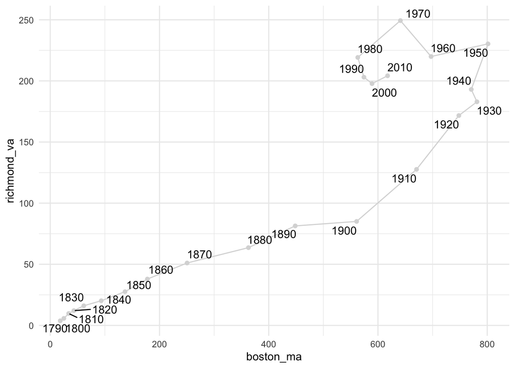

```r
us_cities %>%
  select(city, year, population) %>%
  pivot_wider(names_from = city, values_from = population) %>%
  ggplot(aes(boston_ma, richmond_va)) +
    geom_point(color = "grey85") +
    geom_path(color = "grey85") +
    geom_text_repel(aes(label = year))
```

Note that the `geom_path` geometry is different than the `geom_line` geometry. The latter always connects dots from the smallest x-value to the largest x-value, whereas the path geometry connects the dots in the order they appear in the data.

## Closing Thoughts

The `us` data set is a nice example of how keeping data in a long format makes it relatively easy to work with the data as-is or in various wider formats. In this example, the cities as observations seems to allow more interesting plots. However, the second format will be more useful for building the kinds of time series models we introduce in the applications with temporal data sets.